# Patient Condition Prediction using KNN Model

### Context:

Medical research university X is undergoing a deep research on patients with certain conditions. University has an internal AI team. Due to confidentiality the patient’s details and the conditions are masked by the client by providing different datasets to the AI team for developing a AIML model which can predict the condition of the patient depending on the received test results.

The data consists of biomechanics features of the patients according to their current conditions. Each patient is represented in the data set by six biomechanics attributes derived from the shape and orientation of the condition to their body part.

1. P_incidence
2. P_tilt
3. L_angle
4. S_slope
5. P_radius
6. S_degree
7. Class

```python
import pandas as  pd
import seaborn as sns
import matplotlib.pyplot as plt

import numpy as np
from sklearn.model_selection import train_test_split

from sklearn.neighbors import KNeighborsClassifier
from sklearn.metrics import accuracy_score

from sklearn.preprocessing import MinMaxScaler

from sklearn.metrics import confusion_matrix,classification_report
from sklearn.metrics import plot_confusion_matrix
```

```python
%matplotlib inline
sns.set(color_codes=True)

class color:
   PURPLE = '\033[95m'
   CYAN = '\033[96m'
   DARKCYAN = '\033[36m'
   BLUE = '\033[94m'
   GREEN = '\033[92m'
   YELLOW = '\033[93m'
   RED = '\033[91m'
   BOLD = '\033[1m'
   UNDERLINE = '\033[4m'
   END = '\033[0m'
```

## 1. Import and warehouse data

```python
# Import all dataset
type_normal = pd.read_csv("Part1 - Normal.csv")
type_H = pd.read_csv("Part1 - Type_H.csv")
type_S = pd.read_csv("Part1 - Type_S.csv")
```

```python
# check size of each datset
print(f"Dataset Sizes:")
print(f"Normal: {type_normal.shape}")
print(f"Type_H: {type_H.shape}")
print(f"Type_S: {type_S.shape}")
```

```
Dataset Sizes:
Normal: (100, 7)
Type_H: (60, 7)
Type_S: (150, 7)
```

```python
# merge the different datasets and print shape of new the resultant
frames = [type_normal, type_H, type_S]
dataset = pd.concat(frames)
dataset.head()
```

|  | P_incidence | P_tilt | L_angle | S_slope | P_radius | S_Degree | Class |
| --- | --- | --- | --- | --- | --- | --- | --- |
| 0 | 38.505273 | 16.964297 | 35.112814 | 21.540976 | 127.632875 | 7.986683 | Normal |
| 1 | 54.920858 | 18.968430 | 51.601455 | 35.952428 | 125.846646 | 2.001642 | Normal |
| 2 | 44.362490 | 8.945435 | 46.902096 | 35.417055 | 129.220682 | 4.994195 | Normal |
| 3 | 48.318931 | 17.452121 | 48.000000 | 30.866809 | 128.980308 | -0.910941 | Normal |
| 4 | 45.701789 | 10.659859 | 42.577846 | 35.041929 | 130.178314 | -3.388910 | Normal |

```python
print(f"shape of dataset {dataset.shape}")
```

```
shape of dataset (310, 7)
```

## 2. Data Cleansing

```python
# check the dataset types
dataset.info()
```

```
<class 'pandas.core.frame.DataFrame'>
Int64Index: 310 entries, 0 to 149
Data columns (total 7 columns):
 #   Column       Non-Null Count  Dtype
---  ------       --------------  -----
 0   P_incidence  310 non-null    float64
 1   P_tilt       310 non-null    float64
 2   L_angle      310 non-null    float64
 3   S_slope      310 non-null    float64
 4   P_radius     310 non-null    float64
 5   S_Degree     310 non-null    float64
 6   Class        310 non-null    object
dtypes: float64(6), object(1)
memory usage: 19.4+ KB
```

```python
# Check the different categories of class
dataset['Class'].unique()
```

```
array(['Normal', 'Nrmal', 'Type_H', 'type_h', 'Type_S', 'tp_s'],
      dtype=object)
```

**Standarize the category names**

```python
dataset['Class'].replace(to_replace="Nrmal", value="Normal",inplace=True)
dataset['Class'].replace(to_replace="type_h", value="Type_H",inplace=True)
dataset['Class'].replace(to_replace="tp_s", value="Type_S",inplace=True)
```

```python
#recheck
print(f"Cleaned categories are: {dataset['Class'].unique()}")
```

```
Cleaned categories are: ['Normal' 'Type_H' 'Type_S']
```

```python
#Check for null values
pd.DataFrame(dataset.isnull().sum(), columns=['No. of missing values'])
```

|  | No. of missing values |
| --- | --- |
| P_incidence | 0 |
| P_tilt | 0 |
| L_angle | 0 |
| S_slope | 0 |
| P_radius | 0 |
| S_Degree | 0 |
| Class | 0 |

## 3. Data Analysis and Visualization

```python
dataset.describe()
```

|  | P_incidence | P_tilt | L_angle | S_slope | P_radius | S_Degree |
| --- | --- | --- | --- | --- | --- | --- |
| count | 310.000000 | 310.000000 | 310.000000 | 310.000000 | 310.000000 | 310.000000 |
| mean | 60.496653 | 17.542822 | 51.930930 | 42.953831 | 117.920655 | 26.296694 |
| std | 17.236520 | 10.008330 | 18.554064 | 13.423102 | 13.317377 | 37.559027 |
| min | 26.147921 | -6.554948 | 14.000000 | 13.366931 | 70.082575 | -11.058179 |
| 25% | 46.430294 | 10.667069 | 37.000000 | 33.347122 | 110.709196 | 1.603727 |
| 50% | 58.691038 | 16.357689 | 49.562398 | 42.404912 | 118.268178 | 11.767934 |
| 75% | 72.877696 | 22.120395 | 63.000000 | 52.695888 | 125.467674 | 41.287352 |
| max | 129.834041 | 49.431864 | 125.742385 | 121.429566 | 163.071041 | 418.543082 |

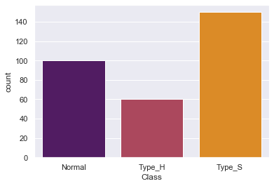

```python
sns.countplot('Class',data=dataset,palette='inferno');
```

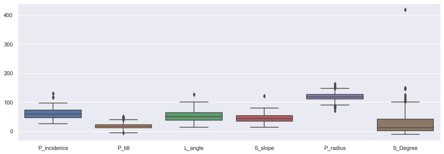

```python
plt.figure(figsize=(15,5))
p = sns.boxplot(data=dataset);
```

### Observations: Data pre-processing

1. We can clean the dataset by removing outliers, especially apparent in S_Degree predictor
2. There is an imbalance of dataset towards Class of Type_S

#### a) Remove Outliers

```python
Q1 = dataset.quantile(0.25)
Q3 = dataset.quantile(0.75)
IQR = Q3 - Q1
print(IQR)
dataset = dataset[~((dataset < (Q1 - 1.5 * IQR)) |(dataset > (Q3 + 1.5 * IQR))).any(axis=1)]
print(f"dataset.shape = {dataset.shape}")
```

```
P_incidence    26.447401
P_tilt         11.453326
L_angle        26.000000
S_slope        19.348766
P_radius       14.758478
S_Degree       39.683625
dtype: float64
dataset.shape = (279, 7)
```

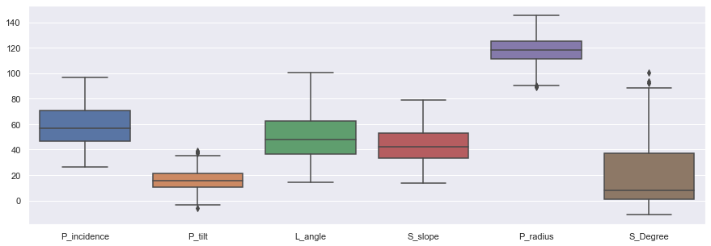

```python
plt.figure(figsize=(15,5))
p = sns.boxplot(data=dataset);
```

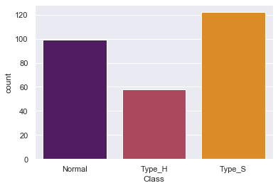

```python
sns.countplot('Class',data=dataset,palette='inferno');
```

```python
print(f"{color.BOLD+color.PURPLE} Datapoints are unevenly balanced with Type_S having more datapoints than Type_H as shown below")
dataset['Class'].value_counts(normalize=True)
```

```
 Datapoints are unevenly balanced with Type_S having more datapoints than Type_H as shown below
```

```
Type_S    0.437276
Normal    0.354839
Type_H    0.207885
Name: Class, dtype: float64
```

```python
from sklearn.utils import resample

# Separate majority and minority classes
df_type_S = dataset[dataset.Class == 'Type_S']
df_normal = dataset[dataset.Class == 'Normal']
df_type_H = dataset[dataset.Class == 'Type_H']

print(f"Before down-sampling: \n{dataset.Class.value_counts()}\n")

df_dsampled_type_S = resample(df_type_S,
                                 replace=False,     # down-sample with replacement
                                 n_samples=58,    # to match majority class
                                 random_state=123) # reproducible results

df_dsampled_normal = resample(df_normal,
                                 replace=False,     # down-sample with replacement
                                 n_samples=58,    # to match majority class
                                 random_state=123) # reproducible results

# Combine majority class with upsampled minority class
df_dsampled = pd.concat([df_dsampled_type_S, df_dsampled_normal,df_type_H])

# Display new class counts
print(f"After down-sampling: \n{df_dsampled.Class.value_counts()}")
df_dsampled.head()
```

```
Before down-sampling:
Type_S    122
Normal     99
Type_H     58
Name: Class, dtype: int64

After down-sampling:
Normal    58
Type_H    58
Type_S    58
Name: Class, dtype: int64
```

|  | P_incidence | P_tilt | L_angle | S_slope | P_radius | S_Degree | Class |
| --- | --- | --- | --- | --- | --- | --- | --- |
| 4 | 76.147212 | 21.936186 | 82.961502 | 54.211027 | 123.932010 | 10.431972 | Type_S |
| 114 | 61.411737 | 25.384364 | 39.096869 | 36.027373 | 103.404597 | 21.843407 | Type_S |
| 74 | 52.204693 | 17.212673 | 78.094969 | 34.992020 | 136.972517 | 54.939134 | Type_S |
| 115 | 56.563824 | 8.961262 | 52.577846 | 47.602562 | 98.777115 | 50.701873 | Type_S |
| 50 | 63.900633 | 13.706204 | 62.124334 | 50.194429 | 114.129243 | 41.422828 | Type_S |

```python
df_dsampled['Class'].value_counts(normalize=True)
```

```
Normal    0.333333
Type_H    0.333333
Type_S    0.333333
Name: Class, dtype: float64
```

```python
dataset.describe()
```

|  | P_incidence | P_tilt | L_angle | S_slope | P_radius | S_Degree |
| --- | --- | --- | --- | --- | --- | --- |
| count | 279.000000 | 279.000000 | 279.000000 | 279.000000 | 279.000000 | 279.000000 |
| mean | 59.024667 | 16.262544 | 50.801811 | 42.762123 | 117.908692 | 20.831704 |
| std | 15.824927 | 8.183678 | 18.169949 | 12.548320 | 11.260183 | 25.142471 |
| min | 26.147921 | -5.845994 | 14.000000 | 13.366931 | 89.307547 | -11.058179 |
| 25% | 46.382174 | 10.600267 | 36.143000 | 33.353537 | 111.179008 | 1.153116 |
| 50% | 56.991404 | 15.844910 | 47.871405 | 42.447102 | 118.363389 | 7.947905 |
| 75% | 70.814813 | 20.980002 | 62.346208 | 52.883139 | 125.208006 | 36.913595 |
| max | 96.657315 | 38.750670 | 100.744220 | 78.794052 | 145.601033 | 100.292107 |

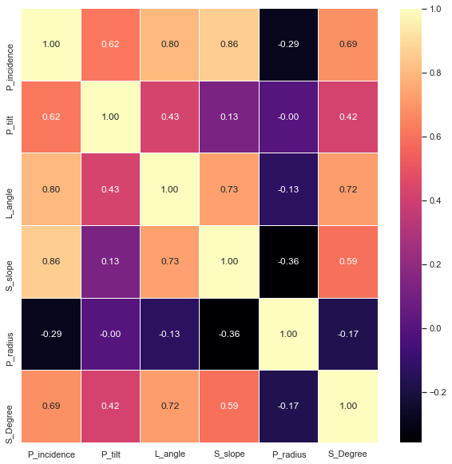

```python
fig,ax = plt.subplots(figsize=(10, 10))
sns.heatmap(dataset.corr(), ax=ax, annot=True, linewidths=0.05, fmt= '.2f',cmap="magma") # the color intensity is based on
plt.show()
```

There are columns which have high correlation values, these can be investigated further to tune the model. From the pair-plot below, we also observe a linear relationship between those columns.

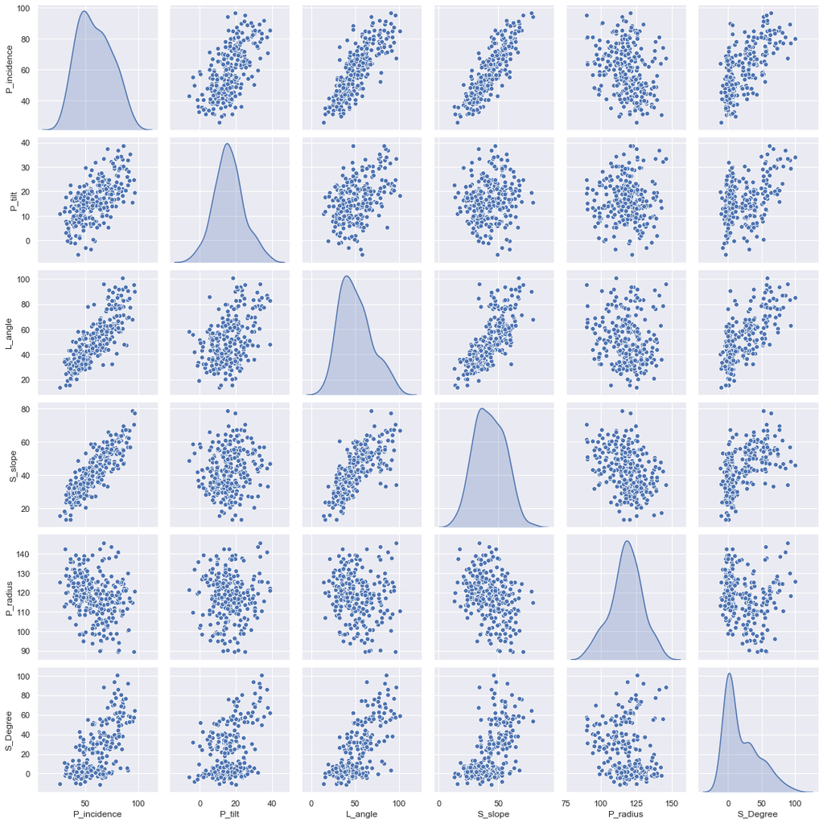

```python
sns.pairplot(dataset, diag_kind = 'kde');
```

## 4. Data Pre-Processing

```python
df_dsampled.info()
```

```
<class 'pandas.core.frame.DataFrame'>
Int64Index: 174 entries, 4 to 59
Data columns (total 7 columns):
 #   Column       Non-Null Count  Dtype
---  ------       --------------  -----
 0   P_incidence  174 non-null    float64
 1   P_tilt       174 non-null    float64
 2   L_angle      174 non-null    float64
 3   S_slope      174 non-null    float64
 4   P_radius     174 non-null    float64
 5   S_Degree     174 non-null    float64
 6   Class        174 non-null    object
dtypes: float64(6), object(1)
memory usage: 10.9+ KB
```

All the dataset are of acceptable type and no further changes would be required.

```python
# segregate target and predictors
X = df_dsampled.drop(['Class'], axis=1)
y = df_dsampled['Class']
```

```python
# split into train and test
X_train, X_test, y_train, y_test = train_test_split(X, y, test_size=0.3, random_state=7)
```

```python
print(f"Shape of: X_train={X_train.shape} ; X_test={X_test.shape} ; y_train={y_train.shape} ; y_test={y_test.shape}")
```

```
Shape of: X_train=(121, 6) ; X_test=(53, 6) ; y_train=(121,) ; y_test=(53,)
```

## 5. Model training, testing and tuning

Apply different values of k and based on the mis-classification score, select the best k value.

```
The optimal number of neighbors (k) is 5
```

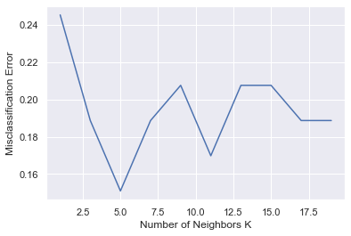

```python
# creating odd list of K for KNN
myList = list(range(1,20))

# subsetting just the odd ones
neighbors = list(filter(lambda x: x % 2 != 0, myList))

# empty list that will hold accuracy scores
ac_scores = []

# perform accuracy metrics for values from 1,3,5....19
for k in neighbors:
    knn = KNeighborsClassifier(n_neighbors=k)
    knn.fit(X_train, y_train)
    # predict the response
    y_pred = knn.predict(X_test)
    # evaluate accuracy
    scores = accuracy_score(y_test, y_pred)
    ac_scores.append(scores)

# changing to misclassification error
MSE = [1 - x for x in ac_scores]

# determining best k
optimal_k = neighbors[MSE.index(min(MSE))]
print(f"{color.BOLD + color.PURPLE}The optimal number of neighbors (k) is {optimal_k}")

# plot misclassification error vs k
plt.plot(neighbors, MSE)
plt.xlabel('Number of Neighbors K')
plt.ylabel('Misclassification Error')
plt.show()
```

```
Accuracy Score: 0.8490566037735849
```

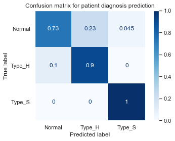

```python
# instantiate learning model with optimal k (k = 17)
knn = KNeighborsClassifier(n_neighbors=5)

# fitting the model
knn.fit(X_train, y_train)

# predict the response
y_pred = knn.predict(X_test)

# evaluate accuracy
print(f"{color.BOLD+color.PURPLE}Accuracy Score: {accuracy_score(y_test, y_pred)}")

disp = plot_confusion_matrix(knn, X_test, y_test, cmap=plt.cm.Blues,
                                 normalize='true');
disp.ax_.set_title("Confusion matrix for patient diagnosis prediction")
plt.grid(False)
```

```python
print(classification_report(y_test, y_pred))
```

```
              precision    recall  f1-score   support

      Normal       0.89      0.73      0.80        22
      Type_H       0.78      0.90      0.84        20
      Type_S       0.92      1.00      0.96        11

    accuracy                           0.85        53
   macro avg       0.86      0.88      0.86        53
weighted avg       0.85      0.85      0.85        53
```

We observe in the classification report that the prediction of Type_S condition of the patient is done best with a f1-score of 96%. The precision of Type_H and the prediction of Normal is not upto the performance and might be improvable with more and better data-points. A low precision-value for Type_H means that the diagnosis of the patient might not be accurate and hence the results of Type_H might need a second look after prediction by a doctor. Low recall scores of Normal indicates that the patient might not be classified as normal and may be tagged as one of the other condition when the patient is actually normal. Also, because of a highly imbalanced dataset, we had to down-sample resulting in low support values for the results. An improvement in the quality of data-set would defintely improve the scores.

**Perform cross-validation score to check for over-fitting**

```python
from sklearn.model_selection import cross_val_score
scores = cross_val_score(knn, X, y, cv=5)
print("%0.2f accuracy with a standard deviation of %0.2f" % (scores.mean(), scores.std()))
```

```
0.80 accuracy with a standard deviation of 0.05
```

We get an 80% score for cross-validation result, which is a deviation of 5% from our model test results.

### Observations: Model Selection

**1. Selecting a model with K-value of 5 gives a good true positive and accuracy score of ~85% as shown in the confusion matrix and classification report.**

**2. Since this is a medical domain model, it is important to reduce false negative to a minimum and true positive to a maximum**